# MLB Data Analysis

STAT 184 Class Project

Mookie Betts

11/10/2024

**How does the payroll and elevation of a Major League Baseball (MLB) team influence its performance, as measured by wins and hitting average?**

## Data Sources

### Dataset 1: Team Elevations

- **Source**: I found this data on a public webpage called Baseballjudgements.com
- **Collected/Maintained by**: The webpage does not identify who collected or maintains this data
- **Collection Date and Purpose**: I don’t have a date for when the data was collected. However, many baseball statisticians find elevation very intriguing when looking at performance and correlations which is probably why this page was created.
- **Case Representation**: Each case represents a team and its elevation.
- **Total Cases**: 30
- **Variables Used**:
  - `Team`: Team abbreviation
  - `Elevation`: Elevation in feet

### Dataset 2: Team Performance

- **Source**: The data was aggregated by my from several different sources on the web. They include Baseball Reference and MLB.com
- **Collected/Maintained by**: MLB collects and maintains this data set and they make it public for people to analyze.
- **Collection Date and Purpose**: The data goes back to 2015 and is through 2024. The purpose is for teams and fans to evaluate and draw conclusions for baseball front offices to make decisions about player personnel.
- **Case Representation**: Each case represents a team’s performance metrics for any given year from 2015 - 2024.
- **Total Cases**: 300
- **Variables Used**:
  - `team`: Team name
  - `team_id`: Team abbreviation
  - `league`: The league in which the team plays, either NL or AL
  - `division`: The division in which the team competes, either east, west, or central
  - `wins`: Number of wins
  - `payroll_total`: Total payroll in dollars
  - `avg_hit_angle`: Average hit angle
  - `avg`: Batting average
  - `slg`: Slugging percentage

# Set Up

```r
#load libraries
install.packages("rvest")
```

```
Error in install.packages : Updating loaded packages
```

```r
install.packages("xml2")
```

```
Error in install.packages : Updating loaded packages
```

```r
library(rvest)
library(xml2)
library(tidyverse)
library(mosaic)
library(dplyr)
library(lubridate)
library(readr)
```

```r
#load mlb data csv file
mlb_raw_data <- read_csv("mlb_raw_data.csv")
# Rename the column 'avg' to 'hit_avg'
mlb_raw_data <- mlb_raw_data %>%
  rename(hit_avg = avg)

View(mlb_raw_data)
```

```r
# Read the HTML content from the webpage
page <- read_html("https://baseballjudgments.tripod.com/id62.html")

# Extract the table
tableList <- page %>%
  html_nodes(css = "table") %>%
  html_table(fill = TRUE)

# Check if any tables were found
if (length(tableList) > 0) {
  # Get the first table
  raw_data <- tableList[[6]]

  # Display the first few rows of the raw data
  print(head(raw_data))

  # Clean the data
  elevation_data <- raw_data %>%
    # Remove unnecessary rows (first 4 rows and any row with NA in X1)
    slice(-1:-4) %>%
    filter(!is.na(X1) & X1 != "") %>%
    # Rename columns
    rename(Team = X1, Elevation = X2)

  # Display the cleaned data
  print(elevation_data)
} else {
  print("No tables found on the webpage.")
}
```

| X1 | X2 |
| --- | --- |
|  | elevation |
|  | above |
|  | sea level |
| TEX | 616 |
| ANA | 160 |

| Team | Elevation |
| --- | --- |
| TEX | 616 |
| ANA | 160 |
| BAL | 130 |
| DET | 596 |
| BOS | 20 |
| CLE | 582 |
| KC | 750 |
| OAK | 42 |
| MIN | 812 |
| TOR | 247 |

[output cut: 20 more lines]

```r
# Rename ARI to AZ, WAS to WSH, and ANA to LAA in the elevation_data dataset
elevation_data <- elevation_data %>%
  mutate(Team = case_when(
    Team == "ARI" ~ "AZ",
    Team == "WAS" ~ "WSH",
    Team == "ANA" ~ "LAA",
    TRUE ~ Team
  ))

# View the updated elevation_data
head(elevation_data)
```

| Team | Elevation |
| --- | --- |
| TEX | 616 |
| LAA | 160 |
| BAL | 130 |
| DET | 596 |
| BOS | 20 |
| CLE | 582 |

```r
NA
```

```r
view(elevation_data)
```

```r
# Ensure the team names match in both datasets
elevation_data$Team <- toupper(elevation_data$Team)  # Convert to uppercase to match team_id

# Join the datasets
combined_data <- left_join(mlb_raw_data, elevation_data, by = c("team_id" = "Team"))

# View the combined data
view(combined_data)
```

```r
glimpse(combined_data)
```

```
Rows: 300
Columns: 14
$ key                   <chr> "2024SD", "2024HOU", "2024AZ", "2024KC", "2024BAL", "2024STL", "2024LAD", "2024M…
$ year                  <dbl> 2024, 2024, 2024, 2024, 2024, 2024, 2024, 2024, 2024, 2024, 2024, 2024, 2024, 20…
$ team                  <chr> "Padres", "Astros", "D-backs", "Royals", "Orioles", "Cardinals", "Dodgers", "Twi…
$ team_id               <chr> "SD", "HOU", "AZ", "KC", "BAL", "STL", "LAD", "MIN", "TOR", "TEX", "WSH", "PHI",…
$ league                <chr> "NL", "AL", "NL", "AL", "AL", "NL", "NL", "AL", "AL", "AL", "NL", "NL", "AL", "N…
$ division              <chr> "West", "West", "West", "Central", "East", "Central", "West", "Central", "East",…
$ wins                  <dbl> 93, 88, 89, 86, 91, 83, 98, 82, 74, 78, 71, 95, 94, 62, 92, 89, 83, 89, 80, 93, …
$ payroll_rank          <dbl> 15, 3, 14, 20, 23, 11, 8, 18, 7, 6, 21, 4, 2, 28, 27, 1, 9, 5, 10, 24, 12, 29, 2…
$ payroll_total         <chr> "$153,765,453", "$237,303,141", "$156,511,716", "$105,219,570", "$94,495,168", "…
$ avg_hit_angle         <dbl> 13.2, 13.5, 12.8, 13.8, 14.5, 13.1, 15.5, 15.0, 13.4, 13.9, 10.7, 12.8, 12.7, 9.…
$ anglesweetspotpercent <dbl> 35.3, 34.1, 32.2, 32.2, 34.3, 34.4, 36.8, 35.1, 34.2, 32.4, 30.5, 34.0, 34.0, 32…
$ hit_avg               <dbl> 0.263, 0.262, 0.263, 0.248, 0.250, 0.248, 0.258, 0.246, 0.241, 0.238, 0.243, 0.2…
$ slg                   <dbl> 0.420, 0.418, 0.440, 0.403, 0.435, 0.392, 0.446, 0.411, 0.389, 0.380, 0.375, 0.4…
$ Elevation             <chr> "13", "38", "1082", "750", "130", "455", "267", "812", "247", "616", "25", "9", …
```

```r
# Convert payroll_total to numeric
mlb_raw_data$payroll_total <- as.numeric(gsub("[\\$,]", "", mlb_raw_data$payroll_total))


# Calculate the average payroll and hit_avg by league and division
summary_table <- mlb_raw_data %>%
  group_by(league, division) %>%
  summarise(
    avg_payroll = mean(payroll_total, na.rm = TRUE),
    avg_hit_avg = mean(hit_avg, na.rm = TRUE)
  ) %>%
  arrange(league, division)
# Print the summary table
print(summary_table)
```

| league | division | avg_payroll | avg_hit_avg |
| --- | --- | --- | --- |
| AL | Central | 106797729 | 0.24934 |
| AL | East | 138773410 | 0.25174 |
| AL | West | 125952776 | 0.24494 |
| NL | Central | 110859832 | 0.24450 |
| NL | East | 136081087 | 0.25146 |
| NL | West | 144458294 | 0.25004 |

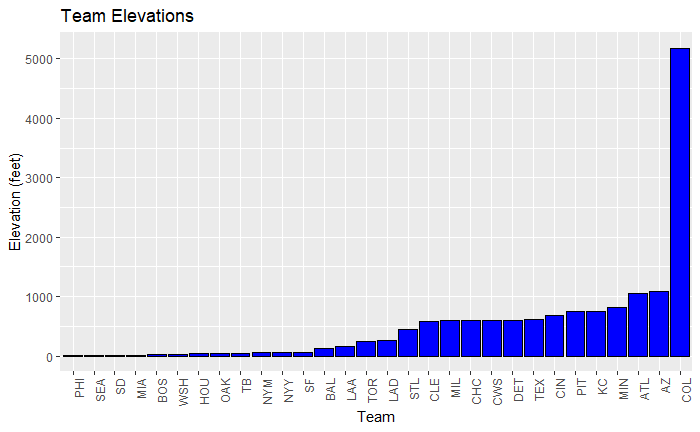

```r
# Convert Elevation to numeric
elevation_data$Elevation <- as.numeric(elevation_data$Elevation)

# Sort the data by Elevation in ascending order
elevation_data <- elevation_data %>%
  arrange(Elevation)

# Plotting team vs elevation with lower elevations on the left and higher on the right
ggplot(elevation_data, aes(x = reorder(Team, Elevation), y = Elevation)) +
  geom_bar(stat = "identity", fill = "blue", color = "black") +
  labs(title = "Team Elevations", x = "Team", y = "Elevation (feet)") +
  theme(axis.text.x = element_text(angle = 90, hjust = 1))
```

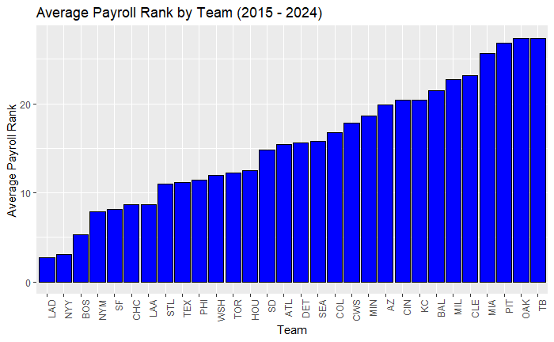

```r
# Convert payroll_rank to numeric if it's not already
mlb_raw_data$payroll_rank <- as.numeric(mlb_raw_data$payroll_rank)

# Calculate the average payroll rank for each team
avg_payroll_rank <- mlb_raw_data %>%
  group_by(team_id) %>%
  summarise(avg_payroll_rank = mean(payroll_rank, na.rm = TRUE)) %>%
  arrange(avg_payroll_rank)  # Sort by average payroll rank

# Plotting the average payroll rank by team with lower ranks to the left and higher to the right
ggplot(avg_payroll_rank, aes(x = reorder(team_id, avg_payroll_rank), y = avg_payroll_rank)) +
  geom_bar(stat = "identity", fill = "blue", color = "black") +
  labs(title = "Average Payroll Rank by Team (2015 - 2024)", x = "Team", y = "Average Payroll Rank") +
  theme(axis.text.x = element_text(angle = 90, hjust = 1))
```

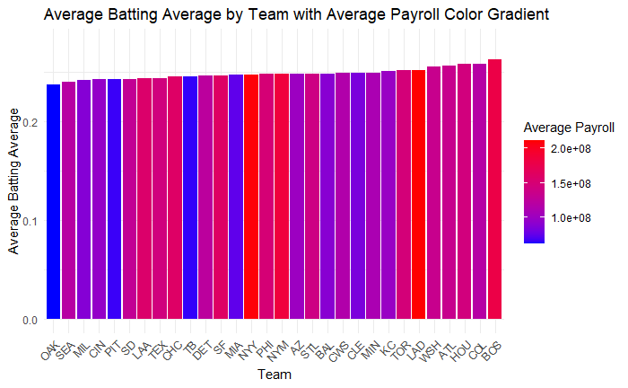

```r
# Remove the dollar signs and commas from payroll_total and convert to numeric
combined_data$payroll_total <- as.numeric(gsub("[\\$,]", "", combined_data$payroll_total))

# Calculate the average payroll and average batting average for each team
combined_data <- combined_data %>%
  group_by(team_id) %>%
  mutate(avg_payroll = mean(payroll_total, na.rm = TRUE),
         avg_hit_avg = mean(hit_avg, na.rm = TRUE))

# Create the bar chart with adjusted y-axis scale
ggplot(combined_data, aes(x = reorder(team_id, avg_hit_avg), y = avg_hit_avg, fill = avg_payroll)) +
  geom_bar(stat = "identity") +
  scale_fill_gradient(low = "blue", high = "red") +
  labs(title = "Average Batting Average by Team with Average Payroll Color Gradient",
       x = "Team",
       y = "Average Batting Average",
       fill = "Average Payroll") +
  theme_minimal() +
  theme(axis.text.x = element_text(angle = 45, hjust = 1)) +
  ylim(0, 0.28)  # Adjust the y-axis scale
```

### Observation 1

- **Performance Data**: Correlation Between Payroll and Performance: There appears to be a general trend where divisions with higher average payrolls also have higher average hit averages. This suggests that teams with more financial resources may be able to invest in better players, leading to improved performance.”

### Observation 2

- **Performance Data**: Analysis of the third chart indicates that teams like the Boston Red Sox (BOS) and Los Angeles Dodgers (LAD) have achieved excellent hitting results with higher payrolls. Conversely, teams like the New York Mets (NYM) havand New York Yankees (NYY) have struggled to see significant results despite extremely high payrolls.Furthermore, the very low payroll teams continue to see lower hitting averages.
- **Efficient Teams**: Teams such as the Atlanta Braves (ATL), Colorado Rockies (COL), Washington Nationals (WSH), and Houston Astros (HOU) have achieved extraordinary results with middle of the road payrolls. This suggests that elevation may play a role in batting averages, as COL and ATL are among the higher elevation teams. However, HOU, being at a lower elevation, indicates that they are able to get high productivity from less expensive players, possibly due to a strong player development program.